# Behavior of RBP-responsive miRNA targets in cancer

Gabrielle Perron

2026-September-25

Determine if the same predicted miRNA targets that were responsive to in vitro RBP inhibition are also dysregulated in TCGA tumors. We are looking at the enrichment of RBP KD-responsive miRNA targets among stabilized/destabilized genes in cancer.

# 1 Load libraries

```r
library(fgsea)
library(tidyverse)
library(data.table)
library(matrixStats)
library(glue)
```

# 2 Load the miRNA activity data and filter for tumors

```r
miR_act <- read.csv(here("TCGA", "output", "supplementary_tables", "TCGA_miRNA_activity.csv"))
miR_act <- miR_act[miR_act$sample_type == "tumor", ]
```

# 3 Load mRNA stability data for RBP KD experiments from ENCODE

```r
stab_HepG2 <- read.csv(here("ENCODE_RBP_KD", "output", "supplementary_tables", "ENCODE_RBP_KD_stab_corr_bias_batch_shRNAoffTargetEffects_HepG2.csv"), row.names=1)
stab_K562 <- read.csv(here("ENCODE_RBP_KD", "output", "supplementary_tables", "ENCODE_RBP_KD_stab_corr_bias_batch_shRNAoffTargetEffects_K562.csv"), row.names=1)
```

# 4 Load mRNA stability data for TCGA samples

One matrix (genes x samples) per cancer type, reused throughout this notebook for both the miRNA-activity-based and the RBP-expression-based enrichment analyses below, so the files are only read once.

```r
tcga_stab_files <- Sys.glob(here("TCGA", "output", "supplementary_tables", "TCGA-*_stability_bias_corr.csv"))
tcga_cancer_types <- tcga_stab_files |>
  basename() |>
  str_extract("(?<=TCGA-)[A-Z]+(?=_stability_bias_corr)")

tcga_stab <- tcga_stab_files |>
  set_names(tcga_cancer_types) |>
  map(function(file) {
    dat <- as.data.frame(fread(file))
    rownames(dat) <- dat[[1]]
    as.matrix(dat[, -1])
  })

names(tcga_stab)
```

```
##  [1] "BLCA" "BRCA" "CHOL" "COAD" "ESCA" "HNSC" "KICH" "KIRC" "KIRP" "LIHC"
## [11] "LUAD" "LUSC" "PRAD" "READ" "STAD" "THCA" "UCEC"
```

# 5 Load predicted miRNA binding matrix

```r
miR_int <- read.csv(here("data", "miRNA_seed_matches_3UTRs2000bp.csv"), header=TRUE, row.names=1)

colnames(miR_int) <- gsub("\\.", "-", colnames(miR_int))

# Define mapping from original names to canonical names
mirna_name_mapping <- tibble(
  original = c(
    "let-7", "miR-101", "miR-10abc", "miR-122", "miR-124", "miR-127", "miR-133abc",
    "miR-135ab", "miR-136", "miR-138", "miR-141", "miR-143", "miR-145", "miR-146ac",
    "miR-150", "miR-153", "miR-155", "miR-15abc", "miR-17", "miR-182", "miR-184",
    "miR-185", "miR-187", "miR-18ab", "miR-191", "miR-193", "miR-194", "miR-196abc",
    "miR-199ab-5p", "miR-19ab", "miR-1ab", "miR-200bc", "miR-203", "miR-204",
    "miR-21", "miR-210", "miR-214", "miR-216a", "miR-216b", "miR-217", "miR-218",
    "miR-22", "miR-221", "miR-23abc", "miR-24", "miR-25", "miR-26ab", "miR-27abc",
    "miR-299", "miR-29abcd", "miR-300", "miR-30abcdef", "miR-31", "miR-326",
    "miR-328a", "miR-329", "miR-338", "miR-33ab", "miR-34ac", "miR-370", "miR-375",
    "miR-376abd", "miR-376c", "miR-377", "miR-383", "miR-433", "miR-448",
    "miR-450a", "miR-487b", "miR-495", "miR-496", "miR-504", "miR-505", "miR-539",
    "miR-543", "miR-544", "miR-551a", "miR-7", "miR-758", "miR-874", "miR-9",
    "miR-93", "miR-96", "miR-99ab", "miR.181abcd"
  ),
  canonical = c(
    "let-7-5p", "miR-101-3p", "miR-10-5p", "miR-122-5p", "miR-124-3p", "miR-127-3p",
    "miR-133-3p", "miR-135-5p", "miR-136-5p", "miR-138-5p", "miR-141-3p", "miR-143-3p",
    "miR-145-5p", "miR-146-5p", "miR-150-5p", "miR-153-3p", "miR-155-5p", "miR-15-5p",
    "miR-17-5p", "miR-182-5p", "miR-184", "miR-185-5p", "miR-187-3p", "miR-18-5p",
    "miR-191-5p", "miR-193-3p", "miR-194-5p", "miR-196-5p", "miR-199-5p", "miR-19-3p",
    "miR-1-3p", "miR-200bc-3p", "miR-203a-3p", "miR-204-5p", "miR-21-5p", "miR-210-3p",
    "miR-214-3p", "miR-216a-5p", "miR-216b-5p", "miR-217", "miR-218-5p", "miR-22-3p",
    "miR-221-3p", "miR-23-3p", "miR-24-3p", "miR-25-3p", "miR-26-5p", "miR-27-3p",
    "miR-299-3p", "miR-29-3p", "miR-381-3p", "miR-30-5p", "miR-31-5p", "miR-326",
    "miR-328-3p", "miR-329-3p", "miR-338-3p", "miR-33-5p", "miR-34-5p", "miR-370-3p",
    "miR-375", "miR-376-3p", "miR-376c-3p", "miR-377-3p", "miR-383-5p", "miR-433-3p",
    "miR-448", "miR-450-5p", "miR-487-3p", "miR-495-3p", "miR-496", "miR-4725-5p",
    "miR-505-3p", "miR-539-5p", "miR-543", "miR-544a-3p", "miR-551-3p", "miR-7-5p",
    "miR-758-3p", "miR-874-3p", "miR-9-5p", "miR-302-3p", "miR-96-5p", "miR-99-5p",
    "miR-181-5p"
  )
)

# Replace names according to the mapping; keep unmatched names unchanged
colnames(miR_int) <- ifelse(
  colnames(miR_int) %in% mirna_name_mapping$original,
  mirna_name_mapping$canonical[
    match(colnames(miR_int), mirna_name_mapping$original)
  ],
  colnames(miR_int)
)
```

# 6 Load the list candidate RBP-miRNA interactions

```r
interactions <- read.csv(here("TCGA", "output", "supplementary_tables", "interactions_RBPKD_ENCODEcellsTissues_TCGA_purityCorrected.csv"))[, -1]
```

# 7 Assign the ENCODE KD cell line used to identify each candidate interaction

```r
interactions <- interactions |>
  left_join(
    readRDS(here("ENCODE_tissues_cell_lines", "output", "rds", "ENCODE_tissues_cell_lines_high_conf_ints.rds")) |>
      distinct(RBP, miRNA, cell_line),
    by = c("RBP", "miRNA")
  )
stopifnot(!anyNA(interactions$cell_line))
interactions
```

```
##            interaction     RBP      miRNA sign cell_line
## 1    DDX55 - miR-29-3p   DDX55  miR-29-3p    -     HepG2
## 2  FAM120A - miR-29-3p FAM120A  miR-29-3p    +     HepG2
## 3    FMR1 - miR-296-3p    FMR1 miR-296-3p    +     HepG2
## 4  IGF2BP2 - miR-17-5p IGF2BP2  miR-17-5p    +     HepG2
## 5     MSI2 - miR-17-5p    MSI2  miR-17-5p    +     HepG2
## 6   PABPC4 - miR-17-5p  PABPC4  miR-17-5p    +     HepG2
## 7    PTBP1 - miR-29-3p   PTBP1  miR-29-3p    -     HepG2
## 8    RPLP0 - miR-29-3p   RPLP0  miR-29-3p    -     HepG2
## 9  SERBP1 - miR-133-3p  SERBP1 miR-133-3p    -     HepG2
## 10    SF1 - miR-199-5p     SF1 miR-199-5p    -     HepG2
## 11 SUPV3L1 - miR-17-5p SUPV3L1  miR-17-5p    +      K562
## 12 SUPV3L1 - miR-19-3p SUPV3L1  miR-19-3p    +      K562
```

# 8 Helper functions for testing enrichment of RBP-KD-responsive miRNA targets among stabilized/destabilized mRNAs in tumors

For each RBP-miRNA interaction, we determine (1) the predicted miRNA targets that respond to RBP knockdown in the direction consistent with the interaction (stabilized upon KD for a “+” interaction, destabilized for a “-” interaction), and (2) their median differential stability upon RBP KD. We then test, for a given sample’s mRNA stability changes (tumor vs. normal), whether these RBP-KD-consistent targets are enriched among the sample’s stabilized or destabilized genes using GSEA, orienting the resulting enrichment score so that a positive value always means “as expected”. `prepare_interaction()` results are cached (`get_prep()`) since the same interaction is often requested more than once, and `fgsea()` is called once per (cancer type, sample) across all interactions tested on that sample rather than once per interaction, which is by far the more expensive pattern given how many tumor samples there are.

```r
ln_to_log2 <- function(x) {
  x / log(2)
}

# Predicted miRNA targets responding to RBP KD in the direction consistent with the interaction sign, and their median differential stability upon RBP KD (log2FC)
prepare_interaction <- function(rbp, mirna, int_sign, cell_line) {

  stopifnot(int_sign %in% c("+", "-"))
  stopifnot(cell_line %in% c("HepG2", "K562"))
  stopifnot(mirna %in% colnames(miR_int))

  stab_kd <- if (cell_line == "HepG2") stab_HepG2 else stab_K562

  kd_cols <- grep(paste0("_", rbp, "_"), colnames(stab_kd))
  stopifnot(length(kd_cols) > 0)

  med_stab_kd <- ln_to_log2(
    data.matrix(stab_kd[, kd_cols, drop = FALSE])
  ) |>
    rowMedians() |>
    setNames(rownames(stab_kd))

  med_stab_kd <- med_stab_kd[!is.na(med_stab_kd)]

  targets <- rownames(miR_int)[miR_int[, mirna] > 0]

  kd_consistent_targets <- if (int_sign == "+") {
    intersect(names(med_stab_kd)[med_stab_kd > 0], targets)
  } else {
    intersect(names(med_stab_kd)[med_stab_kd < 0], targets)
  }

  list(
    med_stab_kd = med_stab_kd,
    targets = targets,
    kd_consistent_targets = kd_consistent_targets
  )
}

# prepare_interaction() is requested more than once for the same (rbp, mirna, int_sign, cell_line) combination (once for the miRNA-activity-based GSEA below, once for the RBP-expression-based GSEA, and again for the example density plots), so cache results and only compute each interaction once.
prep_cache <- new.env()
get_prep <- function(rbp, mirna, int_sign, cell_line) {
  key <- paste(rbp, mirna, int_sign, cell_line, sep = "|")
  if (is.null(prep_cache[[key]])) {
    prep_cache[[key]] <- prepare_interaction(rbp, mirna, int_sign, cell_line)
  }
  prep_cache[[key]]
}

# Test enrichment of several RBP-KD-consistent miRNA target sets (one per interaction) among a single sample's mRNA stability changes (tumor vs. normal) in one fgsea() call. `gene_sets` and `flip` are named by interaction (matching names required). Orient ES so that positive values always mean enrichment in the biologically expected direction.
run_target_gsea_batch <- function(stab_vec, gene_sets, flip, min_size = 10) {

  stab_vec <- stab_vec[!is.na(stab_vec)]
  stab_vec <- sort(ln_to_log2(stab_vec), decreasing = TRUE)

  gene_sets <- map(gene_sets, intersect, names(stab_vec))
  # Skip gene sets with fewer than min_size targets available in the ranked gene list
  gene_sets <- gene_sets[lengths(gene_sets) >= min_size]

  if (length(gene_sets) == 0) {
    return(tibble(name = character(), ES = numeric(), pval = numeric()))
  }

  res <- fgsea(pathways = gene_sets, stats = stab_vec, minSize = min_size)

  tibble(
    name = res$pathway,
    ES = ifelse(flip[res$pathway], -res$ES, res$ES),
    pval = res$pval
  )
}

# For each interaction, summarize the proportion of tested tumors falling into each of four categories: enrichment as/not as expected, and significant/not significant (FDR < 0.05). FDR correction is applied once, across all samples and interactions together.
summarize_enrichment <- function(gsea_df) {

  gsea_df <- gsea_df |>
    filter(!is.na(ES), !is.na(pval)) |>
    mutate(
      padj = p.adjust(pval, method = "fdr")
    )

  gsea_df |>
    group_by(interaction) |>
    summarise(
      n = n(),
      not_expected_sig =
        mean(ES < 0 & padj < 0.05),
      not_expected_ns =
        mean(ES < 0 & padj >= 0.05),
      expected_sig =
        mean(ES > 0 & padj < 0.05),
      expected_ns =
        mean(ES > 0 & padj >= 0.05),
      .groups = "drop"
    )
}

# Diverging stacked bar plot of the summary table produced by summarize_enrichment().
stacked_plot <- function(summary_df) {
  category_levels <- c(
    "Not as expected, not significant",
    "Not as expected, significant",
    "As expected, not significant",
    "As expected, significant"
  )
  category_colors <- setNames(c("#B9D3EE", "#6495ED", "#FFAEB9", "#CD3278"), category_levels)

  # Create a mapping from interaction names to their signs
  int_sign_map <- setNames(interactions$sign, interactions$interaction)

  plot_df <- summary_df |>
    mutate(
      int_sign = int_sign_map[interaction],
      interaction = paste0(interaction, " (", int_sign, ")")
    ) |>
    transmute(
      interaction,
      `Not as expected, significant` = -not_expected_sig,
      `Not as expected, not significant` = -not_expected_ns,
      `As expected, not significant` = expected_ns,
      `As expected, significant` = expected_sig
    ) |>
    pivot_longer(-interaction, names_to = "category", values_to = "proportion") |>
    mutate(category = factor(category, levels = category_levels))

  ggplot(plot_df, aes(x = proportion, y = interaction, fill = category)) +
    geom_col(width = 0.7, colour = "grey30", linewidth = 0.2) +
    geom_vline(xintercept = 0, colour = "black") +
    scale_fill_manual(values = category_colors) +
    scale_x_continuous(labels = scales::percent, limits = c(-1, 1)) +
    labs(x = "Proportion of tumors", y = NULL, fill = NULL) +
    theme_classic() +
    theme(
      legend.position = "right",
      legend.text = element_text(size = 10),
      axis.text = element_text(size = 8),
      axis.title = element_text(size = 10),
      legend.title = element_text(size = 10)
    )
}
```

# 9 Helper functions for the 2D density plots comparing predicted miRNA target stability in a tumor sample to their stability upon RBP KD

```r
# Table of mRNA stability changes in a tumor sample vs. RBP KD, flagging predicted miRNA targets
target_stability_table <- function(stab_vec, med_stab_kd, targets) {
  stab_vec <- ln_to_log2(stab_vec[!is.na(stab_vec)])
  common_genes <- intersect(names(stab_vec), names(med_stab_kd))
  tibble(
    gene = common_genes,
    stab_tumor = stab_vec[common_genes],
    stab_kd = med_stab_kd[common_genes],
    is_target = common_genes %in% targets
  )
}

# Density difference plot (miRNA targets vs. non-targets)
plot_target_density <- function(dat, title, ylab, lims = c(-4, 4, -1, 1), zlim = c(-0.3, 0.3)) {
  targets <- dat |> filter(is_target)
  non_targets <- dat |> filter(!is_target)

  f1 <- MASS::kde2d(targets$stab_tumor, targets$stab_kd, lims = lims, n = 500, h = 0.3)
  f2 <- MASS::kde2d(non_targets$stab_tumor, non_targets$stab_kd, lims = lims, n = 500, h = 0.3)
  zvalues <- pmax(pmin(f1$z - f2$z, zlim[2]), zlim[1])

  par(mar = c(5, 5, 4, 2) + 0.5)
  image(f2$x, f2$y, zvalues,
        zlim = zlim, col = colorRampPalette(c("blue", "white", "red"))(100),
        xlab = "Stability tumor vs normal (log2FC)", ylab = ylab)
  abline(v = 0, h = 0, col = "black", lty = 2)
  title(main = title, font.main = 1)
}
```

# 10 For each interaction, for each TCGA tumor where the differential miRNA activity is significant, use GSEA to determine the enrichment of miRNA targets among stabilized or destabilized mRNAs, and check the agreement with the expectations, **based on miRNA activity**

The direction of interest here is the sign of the miRNA’s differential activity coefficient in the tumor (`direction = 1` if activity increases, i.e. the miRNA destabilizes its targets more; `-1` if it decreases). Because the interaction sign was already used above to select the RBP-KD-consistent target set, the expected position of these targets in the tumor’s stability ranking flips only with this direction, regardless of whether the interaction is activating (“+”) or inhibitory (“-”).

Several interactions share the same miRNA (e.g. `miR-29-3p` and `miR-17-5p` each appear in four interactions), in which case they are tested against exactly the same set of significant tumor samples. Rather than looping over interactions and, for each one, calling `fgsea()` separately for every sample, we first build a table of every (interaction, sample) pair to test, then group by sample and run a single `fgsea()` call per sample across all interactions that use it.

```r
# Precompute the FDR < 0.05 tumor samples for each miRNA once, instead of refiltering miR_act for every interaction that happens to involve that miRNA.
miR_act_sig <- miR_act |>
  filter(FDR < 0.05) |>
  transmute(miRNA, sample = sample_name, cancer_type, direction = sign(coefficient))
miR_act_by_mirna <- split(dplyr::select(miR_act_sig, -miRNA), miR_act_sig$miRNA)
empty_activity_samples <- tibble(sample = character(), cancer_type = character(), direction = numeric())

# One row per (interaction, sample) to test: the RBP-KD-consistent target set for the interaction (cached, computed once per interaction), and whether the ES needs flipping
activity_tasks <- interactions |>
  dplyr::select(interaction, RBP, miRNA, sign, cell_line) |>
  mutate(
    kd_consistent_targets = pmap(
      list(RBP, miRNA, sign, cell_line),
      ~ get_prep(..1, ..2, ..3, ..4)$kd_consistent_targets
    ),
    samples = map(miRNA, ~ miR_act_by_mirna[[.x]] %||% empty_activity_samples)
  ) |>
  unnest(samples) |>
  mutate(flip = direction == 1)

# Batch the GSEA calls: one fgsea() call per (cancer_type, sample), testing all interactions that use that sample at once
gsea_activity_res <- activity_tasks |>
  group_by(cancer_type, sample) |>
  group_modify(function(df, keys) {

    stopifnot(
      keys$cancer_type %in% names(tcga_stab),
      keys$sample %in% colnames(tcga_stab[[keys$cancer_type]])
    )

    stab_vec <- tcga_stab[[keys$cancer_type]][, keys$sample]

    res <- run_target_gsea_batch(
      stab_vec,
      set_names(df$kd_consistent_targets, df$interaction),
      set_names(df$flip, df$interaction)
    )

    df |>
      dplyr::select(interaction, RBP, miRNA, sign) |>
      left_join(res, by = c("interaction" = "name"))
  }) |>
  ungroup()

nrow(gsea_activity_res)
```

```
## [1] 8436
```

```r
saveRDS(gsea_activity_res, here("TCGA", "output", "rds", "TCGAstab_vs_KDstab_miRtar_GSEA_byMirActivity_candidateInts.rds"))
```

## 10.1 Summarize the results as proportions of tested tumors in each category, for each interaction

```r
summary_activity <- summarize_enrichment(gsea_activity_res)
as.data.frame(summary_activity)
```

```
##            interaction    n not_expected_sig not_expected_ns expected_sig
## 1    DDX55 - miR-29-3p 1992      0.004016064      0.25100402    0.4151606
## 2  FAM120A - miR-29-3p 2023      0.000000000      0.29461196    0.1487889
## 3  IGF2BP2 - miR-17-5p   23      0.000000000      0.08695652    0.6521739
## 4     MSI2 - miR-17-5p   23      0.000000000      0.17391304    0.3478261
## 5   PABPC4 - miR-17-5p   22      0.000000000      0.04545455    0.7727273
## 6    PTBP1 - miR-29-3p 1995      0.000000000      0.24611529    0.1804511
## 7    RPLP0 - miR-29-3p 2011      0.001491795      0.30233715    0.2978618
## 8     SF1 - miR-199-5p    2      0.000000000      0.00000000    0.5000000
## 9  SUPV3L1 - miR-17-5p   23      0.000000000      0.13043478    0.5652174
## 10 SUPV3L1 - miR-19-3p  207      0.000000000      0.12560386    0.5990338
##    expected_ns
## 1    0.3298193
## 2    0.5565991
## 3    0.2608696
## 4    0.4782609
## 5    0.1818182
## 6    0.5734336
## 7    0.3983093
## 8    0.5000000
## 9    0.3043478
## 10   0.2753623
```

## 10.2 Stacked bar plot

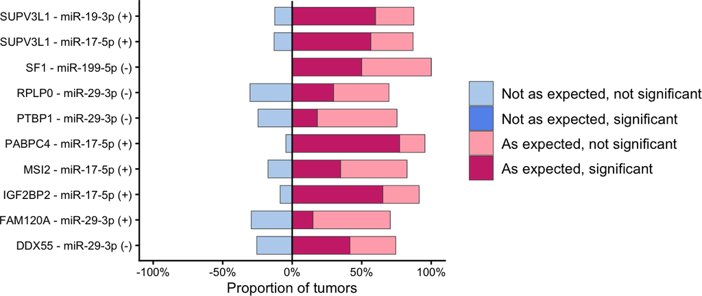

```r
p_activity <- stacked_plot(summary_activity)
p_activity
```

```r
ggsave(
  here("TCGA", "output", "figures", "TCGAstab_vs_KDstab_miRtar_GSEA_candidateInts_byMirActivity.pdf"),
  p_activity, width = 8, height = 2.1
)
```

## 10.3 Smallest % of tumors where the miRNA targets responsive to in vitro RBP inhibition were dysregulated in the expected direction, regardless of significance (interaction with the smallest %)

```r
(summary_activity$expected_sig + summary_activity$expected_ns)*100
```

```
##  [1]  74.49799  70.53880  91.30435  82.60870  95.45455  75.38847  69.61711
##  [8] 100.00000  86.95652  87.43961
```

```r
min(summary_activity$expected_sig + summary_activity$expected_ns)*100
```

```
## [1] 69.61711
```

## 10.4 Average % of tumors with significant expected enrichment across interactions

```r
mean(summary_activity$expected_sig)*100
```

```
## [1] 44.79241
```

```r
range(summary_activity$expected_sig)*100
```

```
## [1] 14.87889 77.27273
```

## 10.5 Largest % of tumors where for the interactions where the miRNA shows a significant change in activity in at least one tumor, the miRNA targets responsive to in vitro RBP inhibition were dysregulated in the UN-expected direction (interaction with the largest %)

```r
max(summary_activity$not_expected_sig)*100
```

```
## [1] 0.4016064
```

# 11 Make two example plots showing the enrichment of miRNA targets, for the positive inferred interaction between SUPV3L1 and miR-19-3p

```r
example_density_plot <- function(rbp, mirna, int_sign, cell_line, sample, cancer_type) {
  prep <- get_prep(rbp, mirna, int_sign, cell_line)
  dat <- target_stability_table(tcga_stab[[cancer_type]][, sample], prep$med_stab_kd, prep$targets)

  p <- plot_target_density(
    dat,
    title = glue("{rbp} - {mirna} ({int_sign})\n{gsub('\\\\.', '-', sample)}"),
    ylab = glue("Stability {rbp} KD in {cell_line}\n(median log2FC)")
  )
  p
}

save_density_plot <- function(rbp, mirna, int_sign, cell_line, sample, cancer_type, filename) {
  prep <- get_prep(rbp, mirna, int_sign, cell_line)
  dat <- target_stability_table(tcga_stab[[cancer_type]][, sample], prep$med_stab_kd, prep$targets)

  pdf(here("TCGA", "output", "figures", filename), width = 3.5, height = 4)
  par(mar = c(5, 5, 4, 2) + 0.5)
  targets <- dat |> filter(is_target)
  non_targets <- dat |> filter(!is_target)

  f1 <- MASS::kde2d(targets$stab_tumor, targets$stab_kd, lims = c(-4, 4, -1, 1), n = 500, h = 0.3)
  f2 <- MASS::kde2d(non_targets$stab_tumor, non_targets$stab_kd, lims = c(-4, 4, -1, 1), n = 500, h = 0.3)
  zvalues <- pmax(pmin(f1$z - f2$z, 0.3), -0.3)

  image(f2$x, f2$y, zvalues,
        zlim = c(-0.3, 0.3), col = colorRampPalette(c("blue", "white", "red"))(100),
        xlab = "Stability tumor vs normal (log2FC)",
        ylab = glue("Stability {rbp} KD in {cell_line}\n(median log2FC)"))
  abline(v = 0, h = 0, col = "black", lty = 2)
  title(main = glue("{rbp} - {mirna} ({int_sign})\n{gsub('\\\\.', '-', sample)}"), font.main = 1)
  dev.off()

  invisible(NULL)
}

save_density_plot("SUPV3L1", "miR-19-3p", "+", "K562", "TCGA.EY.A1G8.01", "UCEC", "TCGA_density_SUPV3L1_miR19_UCEC.pdf")
save_density_plot("SUPV3L1", "miR-19-3p", "+", "K562", "TCGA.DM.A1DA.01", "COAD", "TCGA_density_SUPV3L1_miR19_COAD.pdf")
```

# 12 Enrichment of RBP KD responsive miRNA targets among stabilized/destabilized genes in cancer, with the expectation of target stability change in cancer based **on differential RBP expression**

## 12.1 Load TCGA differential gene expression data from GDCRNAtools (per cancer type differential expression) and log2(RSEM) data (per sample absolute expression); mRNA stability data was already loaded above and is reused here.

```r
DE_files <- Sys.glob(here("data", "*_DGEA_GDCRNATools.rds"))
DE_lst <- DE_files |>
  set_names(str_extract(basename(DE_files), "(?<=TCGA-)[A-Z]+")) |>
  map(readRDS)

logRSEM_files <- list.files(here("data"), pattern = "log2RSEM.csv", full.names = TRUE)
logRSEM_data <- logRSEM_files |>
  set_names(str_extract(basename(logRSEM_files), "^[A-Z]+")) |>
  map(function(file) {
    dat <- as.data.frame(fread(file))
    rownames(dat) <- dat[[1]]
    dat[, -1]
  })

# Keep the same cancer types across the stability, differential expression, and log2(RSEM) data
common_cancers <- Reduce(intersect, list(names(tcga_stab), names(DE_lst), names(logRSEM_data)))
DE_lst <- DE_lst[common_cancers]
logRSEM_data <- logRSEM_data[common_cancers]
common_cancers
```

```
##  [1] "BLCA" "BRCA" "CHOL" "COAD" "ESCA" "HNSC" "KICH" "KIRC" "KIRP" "LIHC"
## [11] "LUAD" "LUSC" "PRAD" "READ" "STAD" "THCA" "UCEC"
```

## 12.2 For each interaction, for each cancer type where the RBP differential expression is significant, and for each tumor within these cancer types where the log2FC(RSEM) between the tumor and the average of normal samples is at least 1 in the direction of the RBP differential expression for that cancer type, determine the expected enrichment of miRNA targets (among stabilized or destabilized mRNAs) based on the direction of the RBP expression change and the type of RBP-miRNA interaction (activating or inhibitory), then run the GSEA.

Here the direction of interest (`rbp_de_dir`) is the sign of the RBP’s own differential expression, which changes stability of the RBP-KD-consistent targets only in combination with the interaction sign (an increase in an activating RBP has the opposite effect on target stability from an increase in an inhibitory RBP) - so, unlike the miRNA-activity-based analysis above, the flip depends on both `rbp_de_dir` and `int_sign` together.

Several interactions share the same RBP (e.g. `SUPV3L1` appears with both `miR-17-5p` and `miR-19-3p`), for which the eligible tumor samples (based on the RBP’s own differential expression) are identical. As above, we cache this per-RBP sample selection and batch the `fgsea()` calls per (cancer_type, sample) across interactions.

```r
# Cancer types/samples where the RBP's differential expression qualifies it for testing, cached per RBP since this does not depend on the miRNA or interaction sign, and several interactions can share the same RBP.
rbp_expr_cache <- new.env()
get_rbp_expr_samples <- function(rbp) {
  if (!is.null(rbp_expr_cache[[rbp]])) return(rbp_expr_cache[[rbp]])

  # Cancer types where the RBP's differential expression is significant, and its direction
  sig_cancers <- imap_dfr(DE_lst, function(de, cancer_type) {

    de_row <- de[de$symbol == rbp, ]

    # Keep only cancer types where:
    # 1. the RBP is present in the DE results
    # 2. the RBP is significant
    # 3. the RBP is also present in the corresponding RSEM data
    if (
      nrow(de_row) == 0 ||
      is.na(de_row$FDR[1]) ||
      de_row$FDR[1] >= 0.05 ||
      !rbp %in% rownames(logRSEM_data[[cancer_type]])
    ) {
      return(NULL)
    }

    tibble(
      cancer_type = cancer_type,
      rbp_de_dir = sign(de_row$logFC[1])
    )
  })

  rbp_expr_cache[[rbp]] <- pmap_dfr(sig_cancers, function(cancer_type, rbp_de_dir) {
    logrsem <- logRSEM_data[[cancer_type]]
    normal_avg <- mean(unlist(logrsem[rbp, grep("-11$", colnames(logrsem))]))

    tumor_samples <- colnames(tcga_stab[[cancer_type]])[grepl("\\.01$", colnames(tcga_stab[[cancer_type]]))]

    map_dfr(tumor_samples, function(sample) {
      logrsem_sample <- gsub("\\.", "-", sample)
      if (!logrsem_sample %in% colnames(logrsem)) {
        return(tibble())
      }
      logrsem_s <- logrsem[rbp, logrsem_sample]
      if (length(logrsem_s) == 0 || is.na(logrsem_s) || is.na(normal_avg)) return(tibble())

      # Keep only samples where RSEM log2FC (tumor vs. avg normal) is at least 1 in the direction of the RBP's differential expression for this cancer type
      diff <- logrsem_s - normal_avg
      passes <- (rbp_de_dir == 1 && diff >= 1) || (rbp_de_dir == -1 && diff <= -1)
      if (!passes) return(tibble())

      tibble(cancer_type = cancer_type, sample = sample, rbp_de_dir = rbp_de_dir)
    })
  })

  rbp_expr_cache[[rbp]]
}

# One row per (interaction, sample) to test.
expression_tasks <- interactions |>
  dplyr::select(interaction, RBP, miRNA, sign, cell_line) |>
  mutate(
    kd_consistent_targets = pmap(
      list(RBP, miRNA, sign, cell_line),
      ~ get_prep(..1, ..2, ..3, ..4)$kd_consistent_targets
    ),
    sign_num = if_else(sign == "+", 1, -1),
    samples = map(RBP, get_rbp_expr_samples)
  ) |>
  unnest(samples) |>
  mutate(flip = rbp_de_dir == sign_num)

# Batch the GSEA calls: one fgsea() call per (cancer_type, sample) across all interactions that use that sample.
gsea_expression_res <- expression_tasks |>
  group_by(cancer_type, sample) |>
  group_modify(function(df, keys) {

    stopifnot(
      keys$cancer_type %in% names(tcga_stab),
      keys$sample %in% colnames(tcga_stab[[keys$cancer_type]])
    )

    stab_vec <- tcga_stab[[keys$cancer_type]][, keys$sample]

    res <- run_target_gsea_batch(
      stab_vec,
      set_names(df$kd_consistent_targets, df$interaction),
      set_names(df$flip, df$interaction)
    )
    df |>
      dplyr::select(interaction, RBP, miRNA, sign) |>
      left_join(res, by = c("interaction" = "name"))
  }) |>
  ungroup()

nrow(gsea_expression_res)
```

```
## [1] 11333
```

```r
saveRDS(gsea_expression_res, here("TCGA", "output", "rds", "TCGAstab_vs_KDstab_miRtar_GSEA_byRBPexr_candidateInts.rds"))
```

## 12.3 Summarize the results as proportions of tested tumors in each category, for each interaction

```r
summary_expr <- summarize_enrichment(gsea_expression_res)

(summary_expr$expected_sig + summary_expr$expected_ns)*100
```

```
##  [1] 58.58653 25.98039 15.91696 46.77181 33.68870 83.15565 71.33183 38.33017
##  [9] 56.36364 71.42857 69.55224 61.60714
```

```r
min(summary_expr$expected_sig + summary_expr$expected_ns)*100
```

```
## [1] 15.91696
```

```r
mean(summary_expr$expected_sig)*100
```

```
## [1] 16.0542
```

```r
range(summary_expr$expected_sig)*100
```

```
## [1]  0.00000 49.89339
```

```r
max(summary_expr$not_expected_sig)*100
```

```
## [1] 21.19403
```

## 12.4 Stacked bar plot

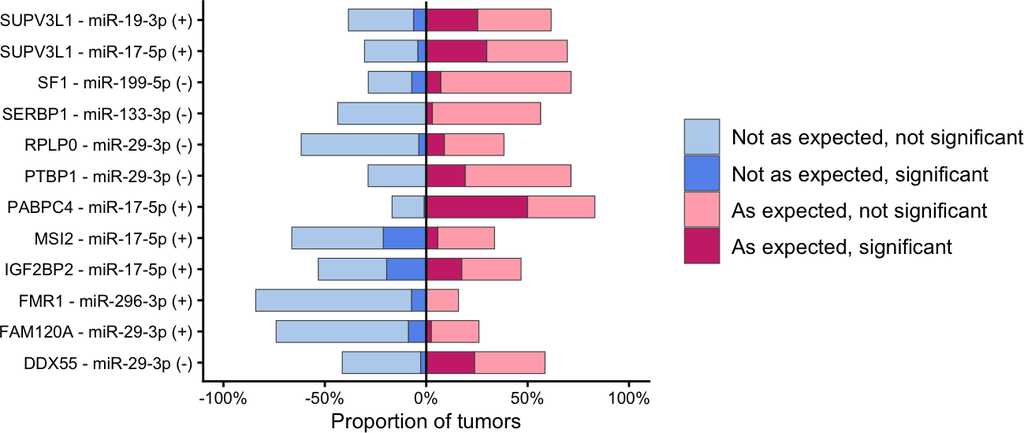

```r
p_expression <- stacked_plot(summary_expr)
p_expression
```

```r
ggsave(
  here("TCGA", "output", "figures", "TCGAstab_vs_KDstab_miRtar_GSEA_candidateInts_byRBPExpression.pdf"),
  p_expression, width = 7, height = 3
)
```

# 13 Save the final list of candidate interactions, filtered to those shown in the miRNA-activity-based stacked bar plot (i.e. previously defined high-confidence interactions with pancancer relevance, where the miRNA also shows a significant change in activity in at least one tumor)

```r
interactions_final <- interactions |>
  filter(interaction %in% summary_activity$interaction)

nrow(interactions_final)
```

```
## [1] 10
```

```r
write.csv(
  interactions_final,
  here("TCGA", "output", "supplementary_tables", "interactions_final.csv"),
  row.names = FALSE
)
```